# Иллюстрации к статье

Вадим Хайтов

12 марта 2019 г

## Рисунок с датами ключевых событий

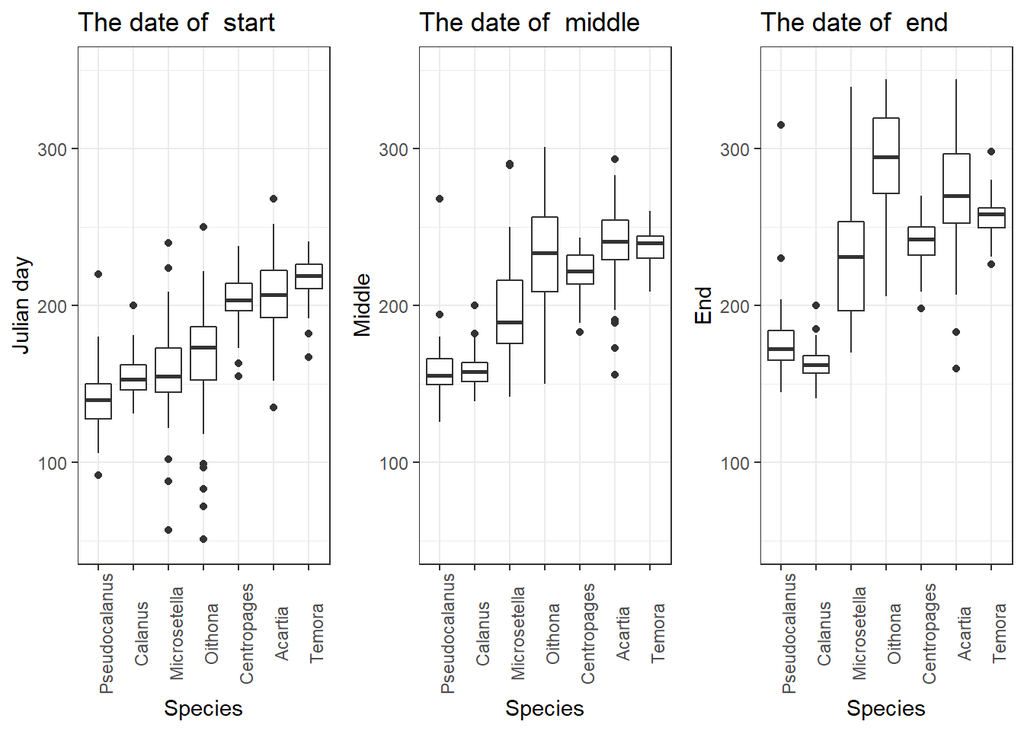

## Многолетние изменения фенологических показателей.

Мне кажется, чтобы не загромождать статью, для демонстрации смешения фенологии лучше выбрать какой-то один фенологический показатель (начало или дату пика). Далее рисунки и параметры моделей давать для него.

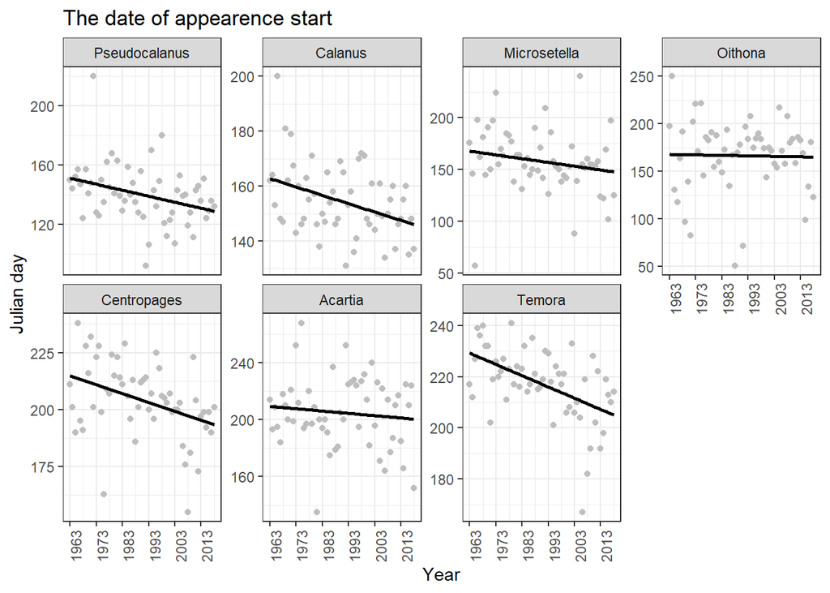

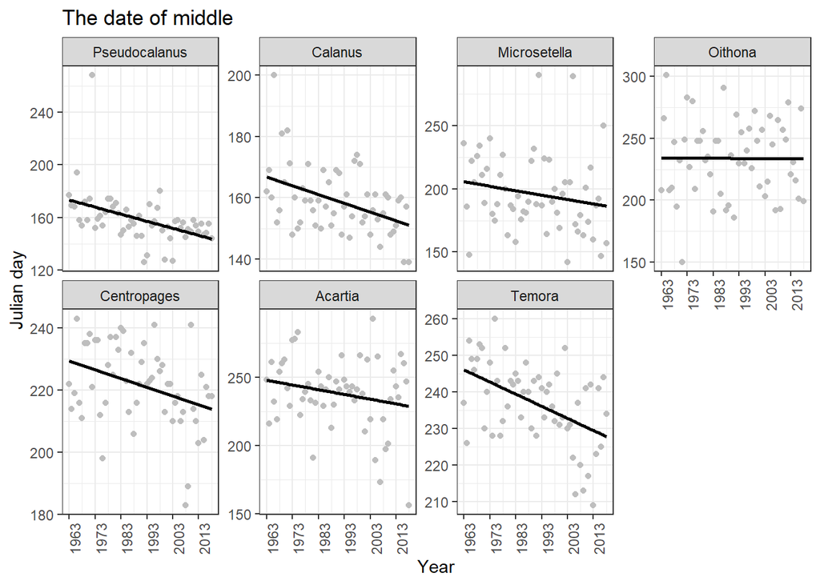

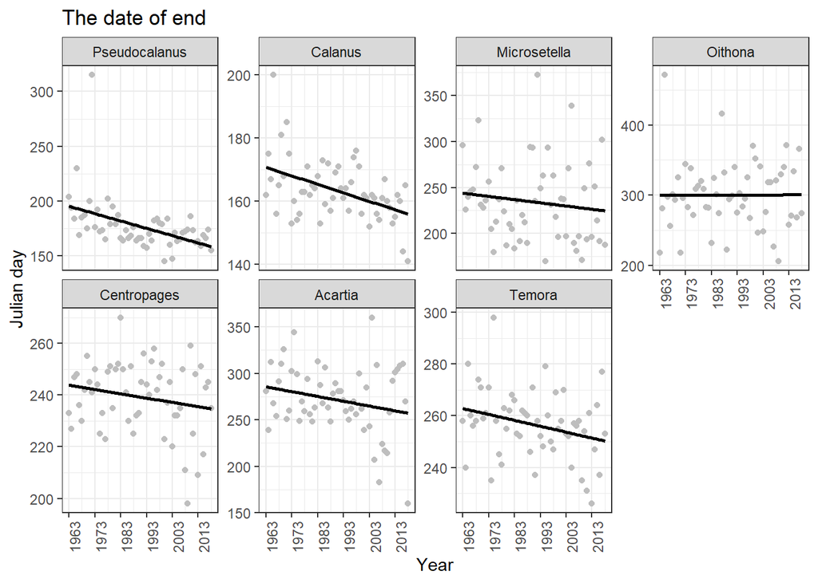

Угловые коэффициенты линейных моделей, описывающих изменение даты ключевых событий.

**Важно!** Оценка достоверности происходит с помощью теста Матела. Но! Для этого анализа берется не каждый отдельно фенологический показатель, а полная фенологическая матрица, которая сравнивается с градиентной модельной матрицей. То есть, дается оценка статистической значимости наличия тренда во всей матрице. Так, по-моему, корректнее, хотя и сложно для объяснения.

Slope terms of linear models fitted and Mantel test p-value for comaprison of phenologiacal matrix of each species with gradient model-matrix

| Species | Slope_Begin | Slope_Peak | Slope_Meadle | Slope_End | Mantel_p |
| --- | --- | --- | --- | --- | --- |
| Pseudocalanus | -0.41 | -0.43 | -0.54 | -0.67 | 0.1034 |
| Calanus | -0.30 | -0.26 | -0.29 | -0.27 | 0.0070 |
| Microsetella | -0.36 | -0.30 | -0.35 | -0.35 | 0.1413 |
| Oithona | -0.05 | 0.65 | 0.00 | 0.01 | 0.0755 |
| Centropages | -0.39 | -0.18 | -0.28 | -0.17 | 0.0476 |
| Acartia | -0.16 | -0.70 | -0.35 | -0.52 | 0.0386 |
| Temora | -0.44 | -0.31 | -0.33 | -0.23 | 0.0026 |

## Факторы, определяющие сдвиги в фенологии сообщества копепод

### Результаты ССА

Полученная модель (при учете всех канонических корреспондентных осей) объясняет 21.6% суммарной изменчивости. При этом на первую и вторую оси приходится 11.2 и 5.1% соответственно (то есть приведенная на рисунке ординация отражает 16.3% общей изменчивости.

### Оценка значимости модели

Permutation significance test of the CCA model

| term | df | ChiSquare | statistic | p.value |
| --- | --- | --- | --- | --- |
| Model | 5 | 0.002834 | 2.756511 | 1e-04 |
| Residual | 50 | 0.010281 |  |  |

Permutation significance test of CCA constrained axis

| term | df | ChiSquare | statistic | p.value |
| --- | --- | --- | --- | --- |
| Model | 5 | 0.002834 | 2.756511 | 1e-04 |
| Residual | 50 | 0.010281 |  |  |

Permutation significance test of each terms included in the CCA model

| term | df | ChiSquare | statistic | p.value |
| --- | --- | --- | --- | --- |
| t_3 | 1 | 0.0004603 | 2.238506 | 0.0332 |
| Ice_clear_G | 1 | 0.0005185 | 2.521778 | 0.0186 |
| Su_end_1 | 1 | 0.0005750 | 2.796310 | 0.0090 |
| Acartia_N | 1 | 0.0005306 | 2.580479 | 0.0144 |
| Microsetella_N | 1 | 0.0010293 | 5.005930 | 0.0001 |
| Residual | 50 | 0.0102810 |  |  |

### Картинка, визуализирующая модель ССА

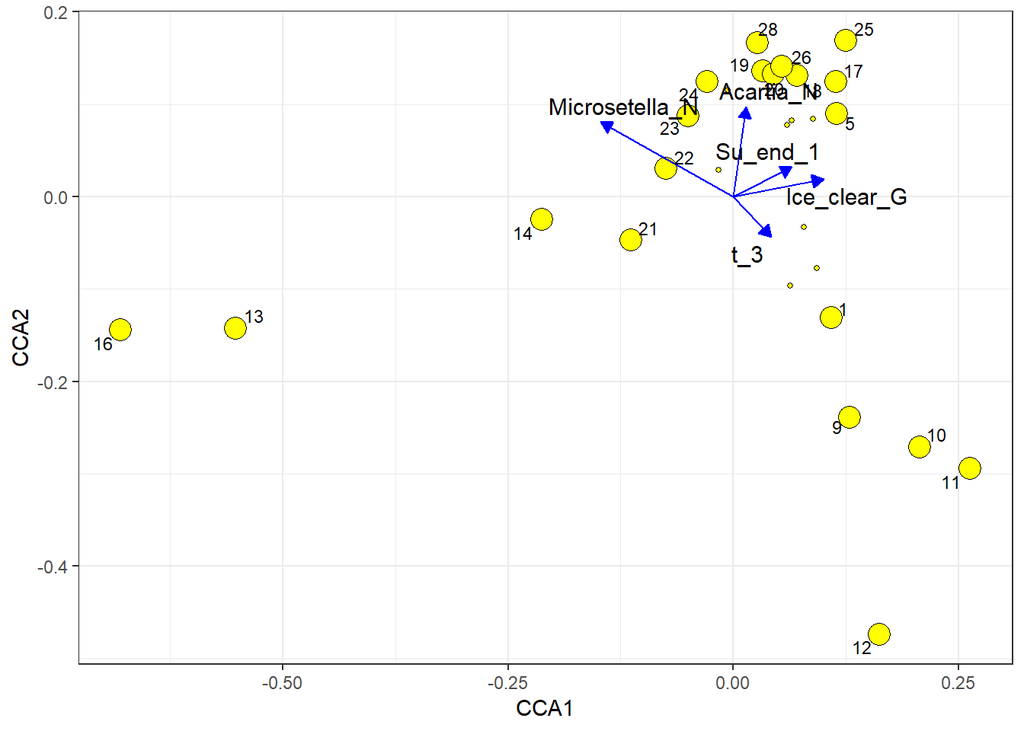

Обозначения фенологических характеристик приведены в следующей таблице.

| Phenological Event | Label | Phenological Event | Label |
| --- | --- | --- | --- |
| Pseudocalanus_Begin | 1 | Acartia_Middle | 22 |
| Calanus_Begin | 5 | Acartia_End | 23 |
| Microsetella_Begin | 9 | Acartia_Peak | 24 |
| Microsetella_Middle | 10 | Temora_Begin | 25 |
| Microsetella_End | 11 | Temora_Middle | 26 |
| Microsetella_Peak | 12 | Temora_Peak | 28 |
| Oithona_Begin | 13 |  |  |
| Oithona_Middle | 14 |  |  |
| Oithona_Peak | 16 |  |  |
| Centropages_Begin | 17 |  |  |
| Centropages_Middle | 18 |  |  |
| Centropages_End | 19 |  |  |
| Centropages_Peak | 20 |  |  |
| Acartia_Begin | 21 |  |  |

## Мнолетние изенения факторов, значимых для фенологии

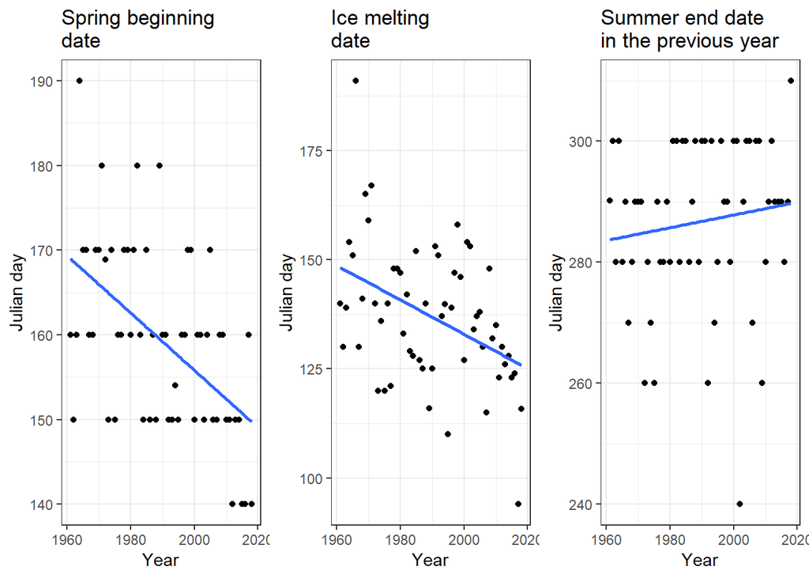

Мне кажется, что не стоит убирать “Summer end date for the previus year”. Все-таки это значимый предктор.

А вот что, на мой взгляд, правильно было бы сделать, так это рисовать это графики не в виде точечной диаграммы, а вот как-то так.

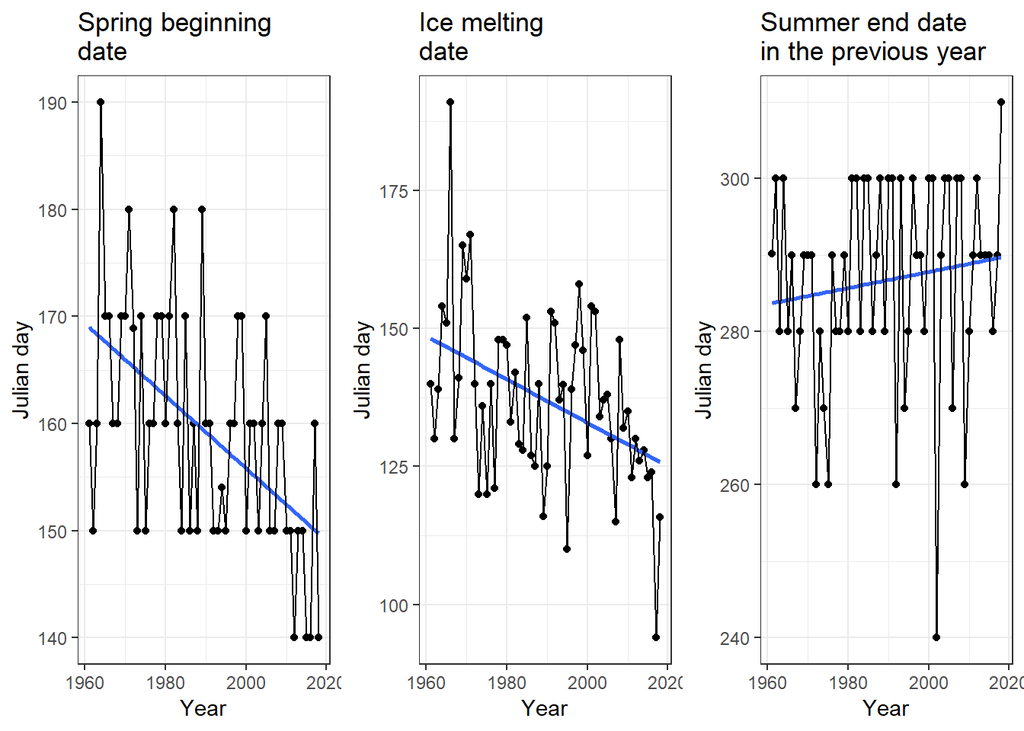

## Многолетняя динамика обилия видов

С этой картинкой есть несколько проблем. Ее, конечно, лучше изображать не в виде точечного графика, а в виде обычного графика значений средних. На него можно нанести аппроксимацию loess-овской регрессией, которая сглаживает имеющиеся графики. Я это переделал на первом рисунке. Но эта линия вообще не о чем. Если хочется вытаскивать какие-то тренды, то надо делать SSA (ну или что-то другое подобное). Так ли это нужно? В принципе, это интересно - разложить динамику на составляющие. Однако это потребует в статье довольно много всего еще (может это лучше оставить на отдельную статью?).

Если хочется просто понять убывает или возрастет численность за 50 лет то надо, на мой взгляд, вписать линейный тренд (т.е. обычную линейную регрессию). Статистическую же значимость линейного тренда оценить все той же мантеловской корреляцией, ка мы это делали в случае с фенологическими данными (см. второй вариант рисунка).

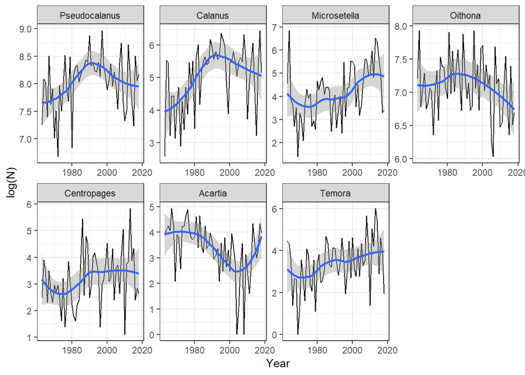

### Второй вариант рисунка

Также, по-моему, лучше приводить максимально первичную картинку, даже не логарифмируя.

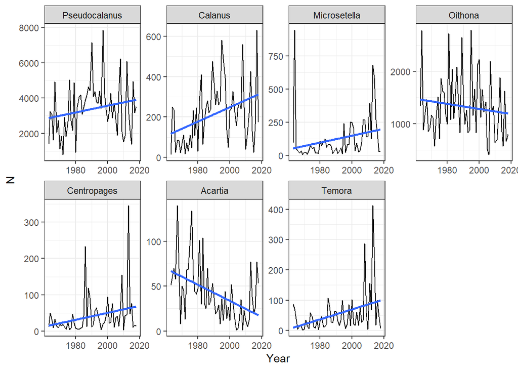

Mantel test p-value for comaprison of copepod abundance dynamics with gradient model-matrix

| Species | Mantel_P_value |
| --- | --- |
| Pseudocalanus | 0.1784 |
| Calanus | 0.0067 |
| Microsetella | 0.0002 |
| Oithona | 0.6510 |
| Centropages | 0.3214 |
| Acartia | 0.0008 |
| Temora | 0.0231 |

Из этих данных следует, что некоторый тренд есть только в динамике Calanus, Microsetella, Acartia и Temora.

## Зависимость обилия видов от параметров среды

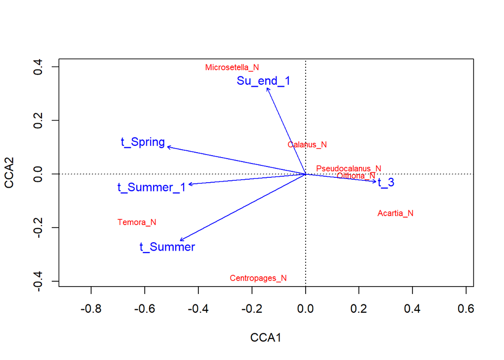

Из этой картинки мы вытянем связь обилия со средовыми показателями, но не с фенологией каждого вида. Связь обилия данного вида с его фенологией придется анализировать отдельно.

## Связь обилия вида и его фенологических показателей

В качестве фенологического показателя взята дата начала.

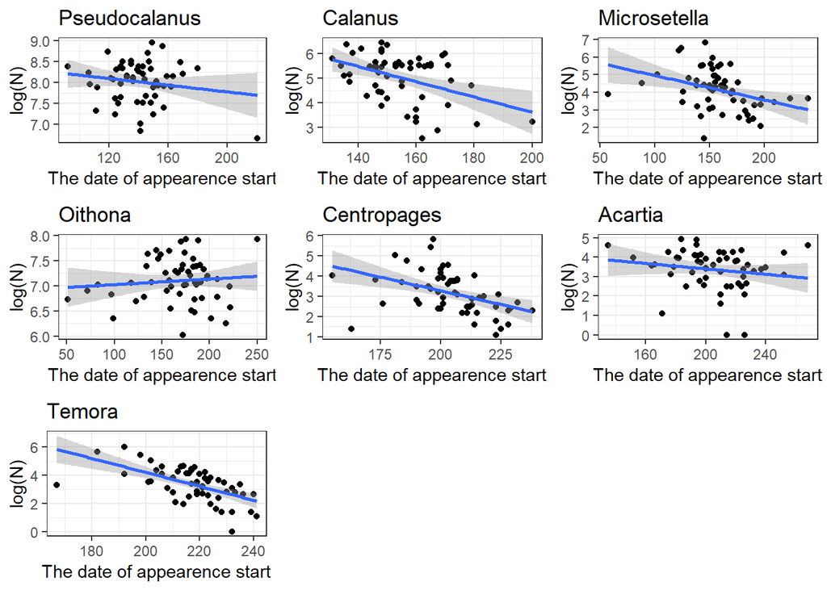

Вот только для оценки значимости связей, здесь придется подумать. Мешает все та же автокоррелированность данных. На рисунке сверху я нарисовал доверительные интервалы как для обычной регрессии, что неправильно. Приведенный ранее подход, основанный на мантеловской корреляции с градиентной матрицей здесь не годится. Здесь придется заниматься подбором оптимальной модели, включающей поправку на автокорреляцию. Занятие не очень простое.

Для каждого вида построить персональную модель, описывающую связь с датой начала появления в планктоне и годом, но с включением моделирования структуры остатков.

То есть модель, в общем, будет иметь вот такой вид

$$Log(N)_s = b_0 + b_1Begin_s + b2Year_s + \varepsilon_s$$

Но придется проверить несколько моделей-кандидатов, для которых будут в модель включены несколько разных способов моделирования автокорреляции остатков (несколько разных автокорреляционных функций). Подробнее про это можно прочитать у Zuur et al, 2009 (chapter 6.1), там разбирается очень похожая история.

Вот что получается.

### Для Acartia

```
## Generalized least squares fit by REML
##   Model: Log_N ~ Begin + Year
##   Data: Abundance_phen[Abundance_phen$Species == species, ]
##        AIC      BIC    logLik
##   172.2869 182.1383 -81.14343
##
## Correlation Structure: AR(1)
##  Formula: ~1
##  Parameter estimate(s):
##       Phi
## 0.2606049
##
## Coefficients:
##                Value Std.Error   t-value p-value
## (Intercept) 63.55035 19.849998  3.201530  0.0023
## Begin       -0.00985  0.004634 -2.126353  0.0381
## Year        -0.02922  0.009917 -2.946068  0.0048
##
##  Correlation:
##       (Intr) Begin
## Begin -0.139
## Year  -0.999  0.092
##
## Standardized residuals:
##        Min         Q1        Med         Q3        Max
## -2.9794263 -0.3009212  0.2109876  0.5438671  2.0689061
##
## Residual standard error: 0.932045
## Degrees of freedom: 56 total; 53 residual
```

У данного вида НЕ будет статистически значимой связи с фенологией. Кроме того, у этой твари есть какие-то автокорреляции высоких порядков, что свидетельствует о наличии каких-то долговременных циклов (период около 4 лет, может больше).

На мой взгляд, эту всю бодягу с долговременными процессами лучше оставить на следующий этап работ с материалом, так как есть еще пара видов с очень подозрительной динамикой, в которой могут существовать долговременные циклы, которые могут быть следствием каких-то внутривидовых или межвидовых отношений.

### Для Calanus

```
## Generalized least squares fit by REML
##   Model: Log_N ~ Begin + Year
##   Data: Abundance_phen[Abundance_phen$Species == species, ]
##        AIC      BIC    logLik
##   163.6697 173.5212 -76.83485
##
## Correlation Structure: AR(1)
##  Formula: ~1
##  Parameter estimate(s):
##       Phi
## 0.2116694
##
## Coefficients:
##                  Value Std.Error   t-value p-value
## (Intercept) -28.229669 18.636546 -1.514748  0.1358
## Begin        -0.021926  0.009091 -2.411974  0.0194
## Year          0.018402  0.009122  2.017387  0.0487
##
##  Correlation:
##       (Intr) Begin
## Begin -0.375
## Year  -0.997  0.307
##
## Standardized residuals:
##        Min         Q1        Med         Q3        Max
## -2.4712620 -0.6871860  0.1703432  0.8457389  1.4340225
##
## Residual standard error: 0.8590172
## Degrees of freedom: 56 total; 53 residual
```

У Calanus связь с фенологией НЕ будет статистически значимой.

Кстати, у данного вида тоже есть какие-то долговременные циклы (с периодом 3-6 лет).

### Для Centropages

```
## Generalized least squares fit by REML
##   Model: Log_N ~ Begin + Year
##   Data: Abundance_phen[Abundance_phen$Species == species, ]
##        AIC      BIC    logLik
##   174.1576 182.0388 -83.07879
##
## Coefficients:
##                  Value Std.Error   t-value p-value
## (Intercept) -11.240664 17.389506 -0.646405  0.5208
## Begin        -0.023323  0.008291 -2.813125  0.0069
## Year          0.009633  0.008371  1.150700  0.2550
##
##  Correlation:
##       (Intr) Begin
## Begin -0.469
## Year  -0.996  0.388
##
## Standardized residuals:
##         Min          Q1         Med          Q3         Max
## -2.79163740 -0.66526004 -0.06178298  0.59512534  2.45485222
##
## Residual standard error: 0.9333328
## Degrees of freedom: 56 total; 53 residual
```

В этом случае, даже с поправкой Бонферрони, мы видим статистически значимую связь с фенологией. У этого вида явных следов автокорреляции не выявляется и вид демонстрирует какие-то очень простые межгодовые (случайные?) колебания численности.

### Для Microsetella

```
## Generalized least squares fit by REML
##   Model: Log_N ~ Begin + Year
##   Data: Abundance_phen[Abundance_phen$Species == species, ]
##        AIC      BIC    logLik
##   178.1322 189.9539 -83.06609
##
## Correlation Structure: ARMA(0,2)
##  Formula: ~1
##  Parameter estimate(s):
##    Theta1    Theta2
## 0.1041445 0.5926096
##
## Coefficients:
##                  Value Std.Error   t-value p-value
## (Intercept) -31.028164 25.101671 -1.236099  0.2219
## Begin        -0.010123  0.003410 -2.968610  0.0045
## Year          0.018490  0.012577  1.470140  0.1474
##
##  Correlation:
##       (Intr) Begin
## Begin -0.132
## Year  -1.000  0.111
##
## Standardized residuals:
##         Min          Q1         Med          Q3         Max
## -2.33281894 -0.71218294  0.03607134  0.45269375  2.81093721
##
## Residual standard error: 1.082579
## Degrees of freedom: 56 total; 53 residual
```

У этого вида выявляется статистически значимая связь обилия со сроками фенологии. Но и здесь пришлось вводить непростую поправку на автокоррелированность. То есть здесь тоже есть существенные подозрения на наличие многолетних циклов (Вероятно с периодом около 3 лет).

### Для Oithona

```
## Generalized least squares fit by REML
##   Model: Log_N ~ Begin + Year
##   Data: Abundance_phen[Abundance_phen$Species == species, ]
##        AIC     BIC    logLik
##   96.91686 104.798 -44.45843
##
## Coefficients:
##                 Value Std.Error    t-value p-value
## (Intercept) 16.205065  7.299044  2.2201627  0.0307
## Begin        0.001064  0.001592  0.6679942  0.5070
## Year        -0.004663  0.003661 -1.2734805  0.2084
##
##  Correlation:
##       (Intr) Begin
## Begin -0.059
## Year  -0.999  0.022
##
## Standardized residuals:
##         Min          Q1         Med          Q3         Max
## -2.27821295 -0.61768521 -0.08011387  0.58203207  1.90716148
##
## Residual standard error: 0.442754
## Degrees of freedom: 56 total; 53 residual
```

Никакой связи с фенологией.

### Для Pseudocalanus

```
## Generalized least squares fit by REML
##   Model: Log_N ~ Begin + Year
##   Data: Abundance_phen[Abundance_phen$Species == species, ]
##        AIC      BIC    logLik
##   104.1411 112.0223 -48.07057
##
## Coefficients:
##                 Value Std.Error    t-value p-value
## (Intercept) -3.411940  8.541658 -0.3994470  0.6912
## Begin       -0.002425  0.003419 -0.7092934  0.4813
## Year         0.005916  0.004206  1.4068112  0.1653
##
##  Correlation:
##       (Intr) Begin
## Begin -0.380
## Year  -0.999  0.330
##
## Standardized residuals:
##        Min         Q1        Med         Q3        Max
## -2.3329769 -0.5598242  0.1194258  0.6451480  1.9324110
##
## Residual standard error: 0.4801309
## Degrees of freedom: 56 total; 53 residual
```

Никакой связи с фенологией.

### Для Temora

```
## Generalized least squares fit by REML
##   Model: Log_N ~ Begin + Year
##   Data: Abundance_phen[Abundance_phen$Species == species, ]
##        AIC      BIC    logLik
##   178.4333 186.3145 -85.21666
##
## Coefficients:
##                   Value Std.Error   t-value p-value
## (Intercept) -0.17562541 19.957374 -0.008800  0.9930
## Begin       -0.04576194  0.010836 -4.223173  0.0001
## Year         0.00676981  0.009373  0.722294  0.4733
##
##  Correlation:
##       (Intr) Begin
## Begin -0.594
## Year  -0.995  0.509
##
## Standardized residuals:
##        Min         Q1        Med         Q3        Max
## -2.6001474 -0.5863846  0.1403142  0.8389565  1.3913424
##
## Residual standard error: 0.9758508
## Degrees of freedom: 56 total; 53 residual
```

Здесь все ОК! Связь хорошая: Чем позднее, тем меньше численность.